# 01_Cohort_Description

Adam Dziorny

2022-10-04

## Overview

The purpose of this markdown is to report information on the cohort necessary to populate “Table 1” of our publication.

## Initialize

First we load the necessary packages:

```r
suppressPackageStartupMessages({

  # Data frame manipulation
  require(dplyr)

  # Graphics and output
  require(ggplot2)

  # Tables
  require(knitr)
  require(kableExtra)
})
```

Ensure the environmental variables are specified:

```r
if (Sys.getenv('PICU_LAB_DATA_PATH') == '' |
    Sys.getenv('PICU_LAB_IMG_PATH') == '' |
    Sys.getenv('PICU_LAB_IN_FILE') == '' |
    Sys.getenv('PICU_LAB_SITE_NAME') == '' |
    Sys.getenv('PICU_LAB_RUN_DATE') == '')
  stop('Missing necessary environmental variables - see README.md')

cat(sprintf('Site: %s\n', Sys.getenv('PICU_LAB_SITE_NAME')))
```

```
## Site: CHOP
```

Set the run date (for file export):

```r
run.date <- Sys.getenv('PICU_LAB_RUN_DATE')

cat(sprintf('Run Date: %s\n', run.date))
```

```
## Run Date: 2022-12-22
```

## Data Input

Load data from the `DATA_PATH` with the associated `IN_FILE`, adding a file separator between them. This should result in loading two data frames: `cohort.df` and `labs.df`.

```r
load(
  file = file.path(
    Sys.getenv('PICU_LAB_DATA_PATH'),
    Sys.getenv('PICU_LAB_IN_FILE')
  )
)
```

## Cohort Counts

Display counts of the ICU admissions (by `ENC_KEY`), hospital encounters (by `HOSP_KEY`) and patients (by `PAT_KEY`) for this site:

```r
# ICU, hospital, and patient counts
cat(sprintf('# Unique ICU encounters: %d\n',
            length(unique(cohort.df$ENC_KEY))))
```

```
## # Unique ICU encounters: 38729
```

```r
cat(sprintf('# unique Hospital encounters: %d\n',
            length(unique(cohort.df$HOSP_KEY))))
```

```
## # unique Hospital encounters: 35646
```

```r
cat(sprintf('# unique Patients: %d\n',
            length(unique(cohort.df$PAT_KEY))))
```

```
## # unique Patients: 22867
```

Gender split. Note that these are distinct to each patient `PAT_KEY`, and so are taken as distinct to those keys first:

```r
cohort.df %>%
  dplyr::distinct(PAT_KEY, SEX) %>%
  dplyr::group_by(SEX) %>%
  dplyr::summarise(
    cnt = n(),
    perc = cnt / length(unique(cohort.df$PAT_KEY)) * 100.
  ) %>%
  knitr::kable(
    col.names = c('Sex', 'Count', '%'),
    digits = c(0,0,2)
  ) %>%
  kableExtra::kable_paper(c("hover", "striped"), full_width = F)
```

| Sex | Count | % |
| --- | --- | --- |
| Female | 10112 | 44.22 |
| Male | 12755 | 55.78 |

Age at admission in years (ensure maximum age is < 18 years):

```r
summary(cohort.df$AGE_ICU_IN / 365.25)
```

```
##      Min.   1st Qu.    Median      Mean   3rd Qu.      Max.
##  0.000002  0.881124  3.277533  5.530726  9.613832 17.999213
```

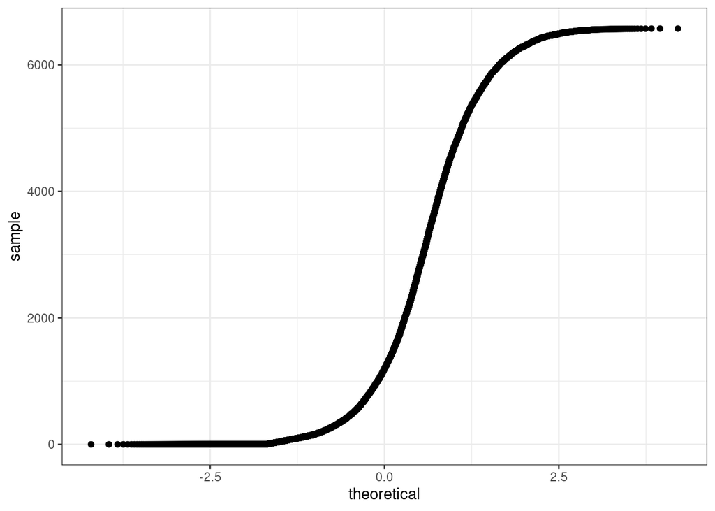

```r
# QQ Plot
cohort.df %>%
  ggplot(aes(sample = AGE_ICU_IN)) +
  stat_qq() +
  theme_bw()
```

```r
# Test for normality:
ks.test(cohort.df$AGE_ICU_IN, 'pnorm')
```

```
##
##  Asymptotic one-sample Kolmogorov-Smirnov test
##
## data:  cohort.df$AGE_ICU_IN
## D = 0.95597, p-value < 2.2e-16
## alternative hypothesis: two-sided
```

ICU length of stay (in days):

```r
summary(cohort.df$ICU_LOS / 24.)
```

```
##     Min.  1st Qu.   Median     Mean  3rd Qu.     Max.
##   0.0007   1.0806   2.0958   5.7027   4.9083 817.2812
```

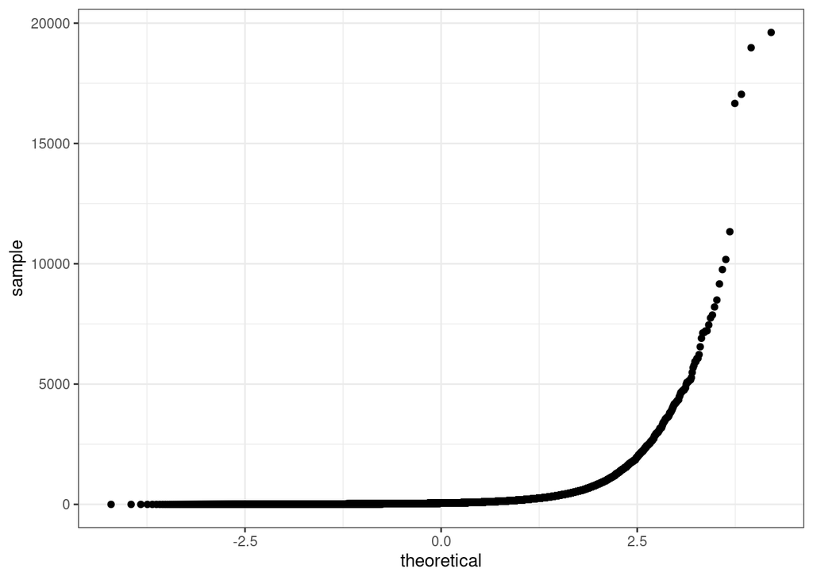

```r
# QQ Plot
cohort.df %>%
  ggplot(aes(sample = ICU_LOS)) +
  stat_qq() +
  theme_bw()
```

```r
# Test for normality:
ks.test(cohort.df$ICU_LOS, 'pnorm')
```

```
##
##  Asymptotic one-sample Kolmogorov-Smirnov test
##
## data:  cohort.df$ICU_LOS
## D = 0.99317, p-value < 2.2e-16
## alternative hypothesis: two-sided
```

Total ICU Days, defined as the ceiling of individual LOS, summed together:

```r
cat(sprintf('Total ICU Days: %d\n',
            sum(ceiling(cohort.df$ICU_LOS / 24.))))
```

```
## Total ICU Days: 239326
```

Hospital mortality (use the column `DISCH_DISP` which has standard values). Note that these are distinct to hospital encounters (`HOSP_KEY`), and so are first taken as the distinct value of those:

```r
cohort.df %>%
  dplyr::distinct(HOSP_KEY, DISCH_DISP) %>%
  dplyr::group_by(DISCH_DISP) %>%
  dplyr::summarise(
    cnt = n(),
    perc = cnt / nrow(cohort.df) * 100.
  ) %>%
  knitr::kable(
    col.names = c('Discharge Disposition', 'Count', '%'),
    digits = c(0,0,2)
  ) %>%
  kableExtra::kable_paper(c("hover", "striped"), full_width = F)
```

| Discharge Disposition | Count | % |
| --- | --- | --- |
| Died | 824 | 2.13 |
| Survived | 34822 | 89.91 |

## Lab Counts

When considering labs, we must first consider what makes a lab “valid”. Hemoglobin labs are valid if they were reported as “final” (that was screened in our queries), and if they have a numeric value. We do not limit by numeric value, but instead report all values here. The only values screened out are `9999999` and `NA` values:

```r
labs.df %>%
  dplyr::filter(COMP_NAME == 'Hgb') %>%
  dplyr::mutate(
    IS_VALID = !is.na(NUM_VAL) & NUM_VAL != 9999999
  ) %>%
  dplyr::group_by(PROC_NAME, IS_VALID) %>%
  dplyr::summarize(
    cnt = n(),
    perc = cnt / sum(labs.df$COMP_NAME == 'Hgb') * 100.,
    per.day = cnt / sum(ceiling(cohort.df$ICU_LOS / 24.)),
    .groups = 'keep'
  ) %>%
  dplyr::ungroup() %>%
  dplyr::arrange(IS_VALID, PROC_NAME) %>%
  knitr::kable(
    col.names = c('Procedure Name', 'Is Valid?', 'Count', '%', 'Per ICU Day'),
    digits = c(0,0,0,2,2)
  ) %>%
  kableExtra::kable_paper(c('striped', 'hover'), full_width = T)
```

| Procedure Name | Is Valid? | Count | % | Per ICU Day |
| --- | --- | --- | --- | --- |
| BG | FALSE | 1637 | 0.35 | 0.01 |
| CBC | FALSE | 1050 | 0.23 | 0.00 |
| ISTAT | FALSE | 415 | 0.09 | 0.00 |
| BG | TRUE | 302811 | 65.14 | 1.27 |
| CBC | TRUE | 124213 | 26.72 | 0.52 |
| ISTAT | TRUE | 34734 | 7.47 | 0.15 |

## Lab Values

Explore the summary and histograms of lab values, for each procedure. Note importantly that these are *not* simultaneous labs at this time - they are all-comers and have not been linked as simultaneous labs.

```r
#'
#' @title Lab Value Descriptions
#'
#' @description Displays graph and summary for lab values by PROC and COMP
#'
#' @param df The lab data frame
#' @param PROC_NAME The Procedure name to display
#' @param COMP_NAME The Component name to display
#'
labValueDescriptions <- function (df, PN, CN) {

  # Limit by the PN and CN
  filt.df <-
    df %>%
    dplyr::filter(PROC_NAME == PN & COMP_NAME == CN) %>%
    dplyr::filter(!is.na(NUM_VAL) & NUM_VAL != 9999999.)

  # Display the numerical summary
  print(summary(filt.df$NUM_VAL))

  # Create a density plot and print (display)
  p <-
    filt.df %>%
    ggplot(aes(x = NUM_VAL)) +
    geom_density(fill = 'blue', alpha = 0.5) +
    ggtitle(paste0('Proc: ',PN,', Comp: ', CN)) +
    xlab('Numerical Value') +
    ylab('Density') +
    theme_bw()


  print(p)
}
```

Describe the lab values for each type:

```r
for ( PN in unique(labs.df$PROC_NAME) )
  labValueDescriptions(df = labs.df, PN = PN, CN = 'Hgb')
```

```
##    Min. 1st Qu.  Median    Mean 3rd Qu.    Max.
##    0.00    9.20   10.60   10.88   12.30   25.40
```

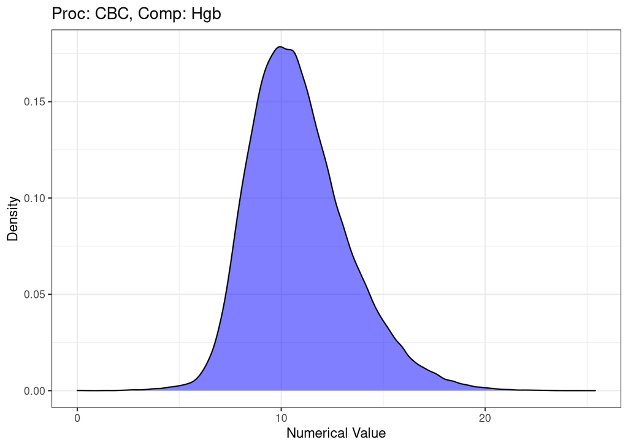

```
##    Min. 1st Qu.  Median    Mean 3rd Qu.    Max.
##    2.00   10.30   11.90   12.12   13.70   37.80
```

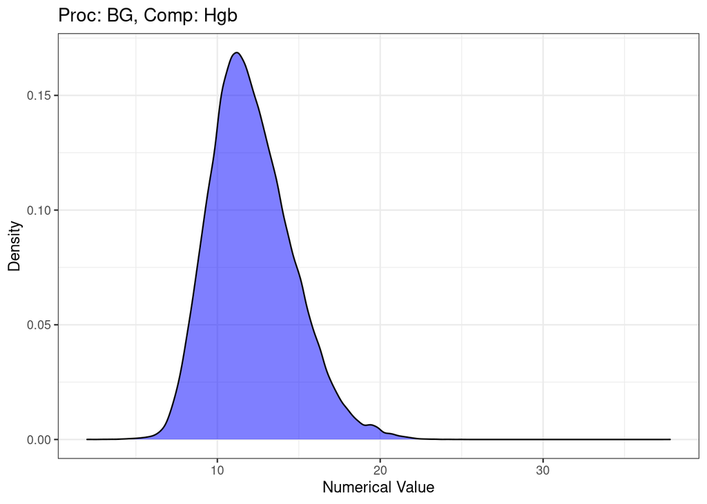

```
##    Min. 1st Qu.  Median    Mean 3rd Qu.    Max.
##    3.40    9.90   11.90   12.17   13.90   25.50
```

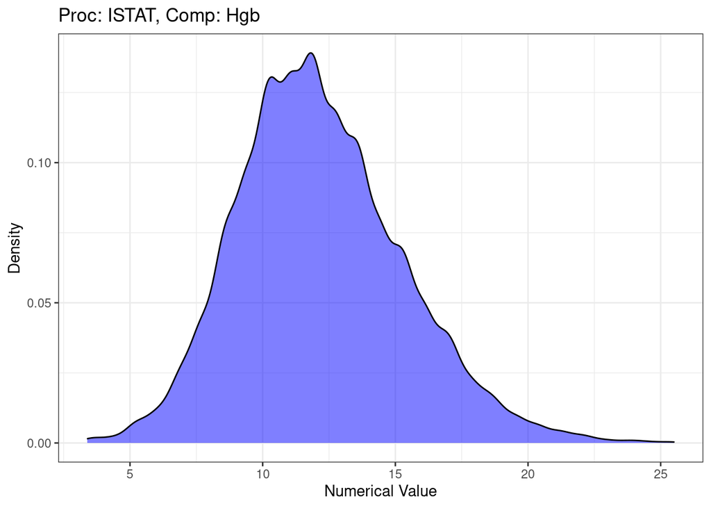

```r
rm(PN)
```

## Join Range

Here for the first time we create a joined data frame of “simultaneously” collected values. This is in quotes because we must define some time threshold, beyond which the labs are not considered “simultaneous” anymore. We will join and look at the count of labs which meet this criteria, across a range of time thresholds.

```r
#'
#' @title Time Threshold Graph
#'
#' @description Joins CN across PNs and plot collected time difference by cutoff
#'
#' @param df The lab data frame
#' @param PN A 2-element list of characters naming the PROC_NAME of interest
#' @param CN A char naming the COMP_NAME of interest
#' @param to.save If TRUE, saves out, otherwise does not save output list
#' @param to.return If TRUE, returns the output list, otherwise returns NA
#'
#' @returns A list of two elements:
#'     cutoffs := The cutoffs data frame containing counts for each minute cutoff
#'     fig := The ggplot figure
#'
timeThresholdGraph <- function (df, PN, CN,
                                to.save = T, run.date = NA, to.return = F) {

  if (length(PN) != 2)
    stop('Must pass PN as list of length 2')

  if (any(is.na(run.date)) & to.save)
    stop('If `to.save` is TRUE, must specify a run date')

  # Filter to remove the non-numeric rows
  filter.df <-
    df %>%
    dplyr::filter(!is.na(NUM_VAL) & NUM_VAL != 9999999.) %>%
    dplyr::filter(COMP_NAME == CN)

  cat(sprintf('Number of component numeric rows in input data frame: %d\n',
              nrow(filter.df)))

  # Filter by PN and join to create full data frame
  joined.df <-
    dplyr::inner_join(
      x = filter.df %>%
        dplyr::filter(PROC_NAME == PN[1]) %>%
        dplyr::select(ENC_KEY, COLLECTED_DT, NUM_VAL),
      y = filter.df %>%
        dplyr::filter(PROC_NAME == PN[2]) %>%
        dplyr::select(ENC_KEY, COLLECTED_DT, NUM_VAL),
      by = c('ENC_KEY'),
      suffix = c('.x', '.y')
    )

  # Join using base R, by column number
  #   [[2]] is PN[1] COLLECTED_DT
  #   [[4]] is PN[2] COLLECTED_DT
  joined.df$COLL_TIME_DIFF_MIN <-
    as.numeric(joined.df[[2]] - joined.df[[4]], units = 'mins')

  cat(sprintf('Number of rows in joined data frame: %d\n',
            nrow(joined.df)))

  # Generate cutoffs data frame
  cutoffs.df <-
    data.frame(
      cutoffs = seq(from = 0, to = 90, by = 1)
    )

  # Count the absolute value of time differences less than each cutoff value
  cutoffs.df$in.range.cnt <-
    sapply(
      cutoffs.df$cutoffs,
      function (x) sum(abs(joined.df$COLL_TIME_DIFF_MIN) < x)
    )

  # Generate the figure and display
  p <-
    cutoffs.df %>%
    ggplot(aes(x = cutoffs, y = in.range.cnt)) +
    geom_line() +
    #geom_vline(aes(xintercept = 15), color = 'red') +
    xlab('Cutoff, Minutes Between Collected Time') +
    ylab('Count of included labs') +
    scale_y_continuous(limits = c(0, max(cutoffs.df$in.range.cnt))) +
    theme_bw()

  print(p)

  # Create the output list which will either be saved or returned
  output.list <-
    list(
      cutoffs = cutoffs.df,
      fig = p
    )

  # Save
  if (to.save) {
    save(
      file = file.path(
        Sys.getenv('PICU_LAB_DATA_PATH'),
        paste0(
          Sys.getenv('PICU_LAB_SITE_NAME'),
          '_thresholds_',
          PN[1],'-',PN[2],'_',
          run.date,'.rData'
        )
      ),
      p
    )
  }

  # Return
  if (to.return)
    return(output.list)
}
```

Run the time threshold graph for both PROC options (if they exist):

```
## Number of component numeric rows in input data frame: 461758
## Number of rows in joined data frame: 10598393
```

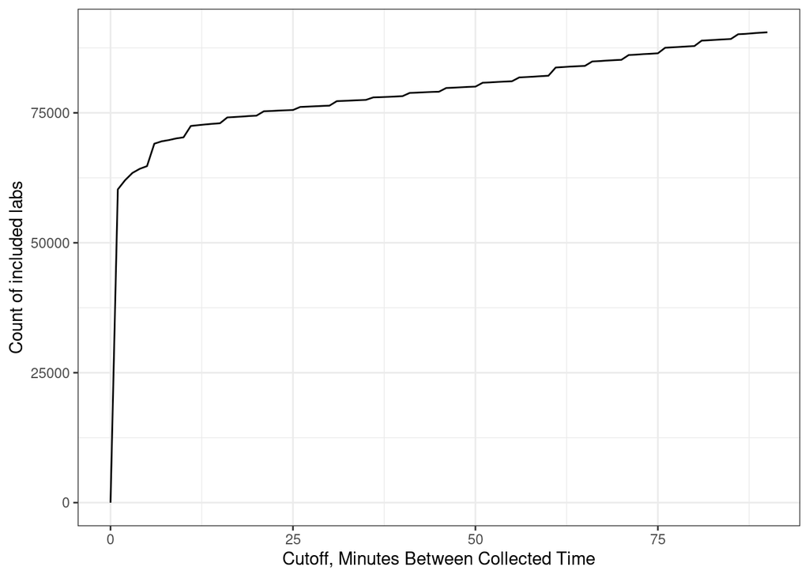

```
## Number of component numeric rows in input data frame: 461758
## Number of rows in joined data frame: 837776
```

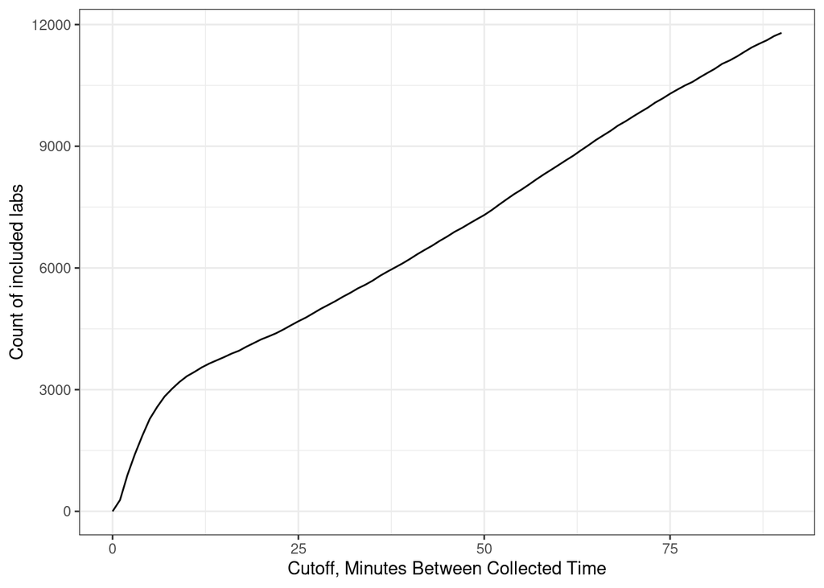

```r
for (proc.option in c('BG', 'ISTAT')) {

  if (proc.option %in% unique(labs.df$PROC_NAME)) {
    timeThresholdGraph(
      df = labs.df,
      PN = c('CBC', proc.option),
      CN = 'Hgb',
      to.save = T,
      run.date = run.date
    )
  }

}
```